## Boston Marathon Data

### Inference for a Difference in Means

### Read the Data

- This is code taken from the lecture notes which does substantial cleaning of the raw data.

```r
bm_orig = read_table("../../data/TIM.txt",
                col_types = cols(.default = col_double()))

bm = bm_orig %>%
  filter(!is.na(`K40-Fin`)) %>%
  filter(Year < 2013) %>%
  arrange(Year, BibNum) %>%
  select(-starts_with("Start"), -HalfMar, -Age2014) %>%
  mutate(Sex = case_when(
    Gender1F2M == 1 ~ "female",
    Gender1F2M == 2 ~ "male")) %>%
  mutate(Time = pmap_dbl(select(., starts_with("K")), sum)) %>%
  mutate(age1 = case_when(
    Age < 35 ~ 18,
    Age >= 80 ~ 80,
    TRUE ~ floor(Age/5)*5),
    age2 = case_when(
      Age < 35 ~ 34,
      TRUE ~ age1 + 4),
    Age_Range = case_when(
      age1 == 80 ~ "80 and older",
      TRUE ~ str_c(age1,"-",age2))) %>%
  select(-Gender1F2M, -age1, -age2) %>%
  relocate(BibNum, Year, Sex, Age, Age_Range, Time)
```

### Data for comparing 2010 and 2011 women

- Create a single data frame in a long format with one row per runner for these two years combined.

```r
prob1 = bm %>%
  filter(Sex == "female" & Age_Range == "18-34" &
           between(Year, 2010, 2011)) %>%
  select(Year, Sex, Age, Age_Range, Time)

glimpse(prob1)
```

```
## Rows: 7,137
## Columns: 5
## $ Year      <dbl> 2010, 2010, 2010, 2010, 2010, 2010, 2010, 2010, 2010, 2010, …
## $ Sex       <chr> "female", "female", "female", "female", "female", "female", …
## $ Age       <dbl> 28, 24, 23, 30, 26, 29, 26, 27, 23, 29, 22, 30, 26, 28, 34, …
## $ Age_Range <chr> "18-34", "18-34", "18-34", "18-34", "18-34", "18-34", "18-34…
## $ Time      <dbl> 180.85, 197.73, 173.75, 174.58, 170.30, 180.09, 207.92, 208.…
```

```r
print(prob1, n = 10)
```

```
## # A tibble: 7,137 × 5
##     Year Sex      Age Age_Range  Time
##    <dbl> <chr>  <dbl> <chr>     <dbl>
##  1  2010 female    28 18-34      181.
##  2  2010 female    24 18-34      198.
##  3  2010 female    23 18-34      174.
##  4  2010 female    30 18-34      175.
##  5  2010 female    26 18-34      170.
##  6  2010 female    29 18-34      180.
##  7  2010 female    26 18-34      208.
##  8  2010 female    27 18-34      208.
##  9  2010 female    23 18-34      190.
## 10  2010 female    29 18-34      189.
## # ℹ 7,127 more rows
```

### EDA

#### Plots

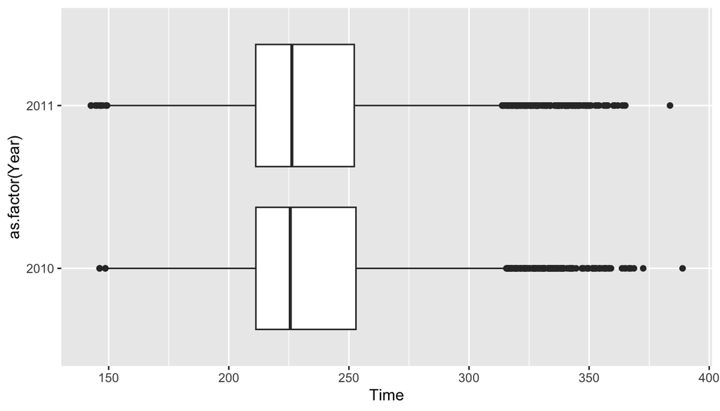

```r
ggplot(prob1, aes(x = Time, y = as.factor(Year))) +
  geom_boxplot()
```

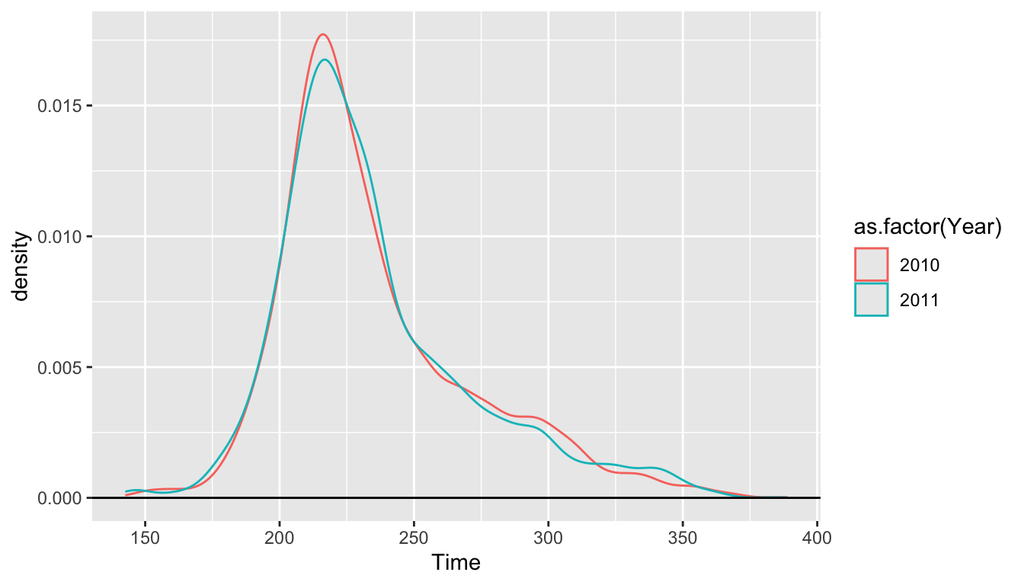

```r
ggplot(prob1, aes(x = Time, color = as.factor(Year))) +
  geom_density() +
  geom_hline(yintercept = 0)
```

- Note that both plots show very similar distributions of observed times for the two years with similar centers, spread, skewness, and shape.

#### Numerical Summaries

```r
prob1_sum = prob1 %>%
  group_by(Year) %>%
  summarize(mean = mean(Time),
            sd = sd(Time),
            n = n(),
            se = sd / sqrt(n))

prob1_sum %>%
  as.data.frame()
```

```
##   Year     mean       sd    n        se
## 1 2010 235.5062 36.16750 3557 0.6064242
## 2 2011 235.2337 36.59875 3580 0.6116807
```

#### CI Calculations Using Tidyverse Commands

```r
### Point estimate = difference in sample means
### Note that diff() calculates x[2] - x[1], so -diff() will show x[1] - x[2]

est = prob1_sum %>%
  summarize(est = -diff(mean)) %>%
  pull(est)

est
```

```
## [1] 0.2724784
```

```r
### standard error

se = prob1_sum %>%
  summarize(se = sqrt(sum(se^2))) %>%
  pull(se)

se
```

```
## [1] 0.8613382
```

```r
### Welch degrees of freedom

df = prob1_sum %>%
  summarize(df = sum(se^2)^2 / sum(se^4 / (n-1))) %>%
  pull(df)

df
```

```
## [1] 7134.791
```

```r
### Quantile

t_crit = qt(0.975, df)

t_crit
```

```
## [1] 1.960297
```

```r
#### Confidence Interval
ci = est + c(-1,1) * t_crit * se
ci
```

```
## [1] -1.416000  1.960957
```

### CI Using t.test()

- First, get a base R vector with each sample

```r
times_2010 = prob1 %>%
  filter(Year == 2010) %>%
  pull(Time)

times_2011 = prob1 %>%
  filter(Year == 2011) %>%
  pull(Time)
```

- Then, use `t.test()`.

```r
t.test(times_2010, times_2011)
```

```
##
##  Welch Two Sample t-test
##
## data:  times_2010 and times_2011
## t = 0.31634, df = 7134.8, p-value = 0.7518
## alternative hypothesis: true difference in means is not equal to 0
## 95 percent confidence interval:
##  -1.416000  1.960957
## sample estimates:
## mean of x mean of y
##  235.5062  235.2337
```

- Note this is **much easier** than doing the calculation by hand.

#### Interpretation

> We are 95% confident that the true difference in population means for the times of female Boston Marathon finishers (2010 - 2011) is between $-1.42$ and 1.96 minutes.
- In other words, it is plausible (at a 95% confidence level) for the population mean from 2010 to be from 1.42 minutes smaller (faster) than to 1.96 minutes greater (slower) than the corresponding 2011 population mean.
- Note that the value 0 is in the interval, meaning no mean difference between the two years is one of many plausible explanations of the data.

#### Notes

- The sample means were 235.51 minutes in 2010 and 235.23 minutes in 2011, a difference of about 0.28 minutes, or about 17 seconds.
  - In a race where the mean finishing time is nearly four hours, a shift of about 17 seconds in the mean finish time is not important.
- The individual sample standard deviations are 36.2 and 36.6 minutes.
  - It is not at all unusual for individual’s finish times to be more than 70 minutes (roughly 2 standard deviations) from the mean.
- The large sample sizes (3557 in 2010, 3580 in 2011) mean that the standard errors of the sample means are both about 0.61 minutes, or 37 seconds.
- The standard error of the difference in sample means is about 0.86 minutes, or nearly 52 seconds.
  - This implies that just by chance, it would not be that unusual for the observed difference in sample mean times to differ from the true population mean difference by nearly a minute.
- The Welch degrees of freedom, 7134.8, is very close to the sum of the two individual sample degrees of freedom, 7135.
  - This is because the sample sizes and standard deviations are both very close to each other.